# Weekly Energy Charts

October 07, 2022

[Sign up here to get on our email list](https://docs.google.com/forms/d/e/1FAIpQLSckqeGjUvIlhveVyjmkXe913tzQRLANqPNQzEZTUQD2hQxH8g/viewform?usp=pp_url)

# Featured Stories

## Oil and Gas Emissions in Canada

#### [Andrew Leach](https://ca.linkedin.com/in/leach-econ)

I’ve spent a lot of time this week thinking about the oil and gas cap that is part of the federal government’s climate change plans. We know that oil and gas is both Canada’s largest and fastest-growing source of GHG emissions. We also know that oil sands are a big part of that growth. However, sometimes, a picture is worth a thousand words.

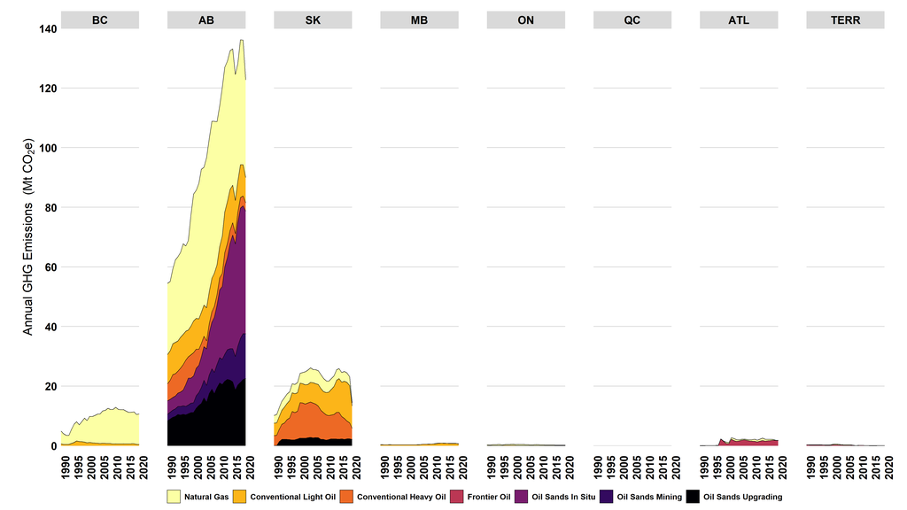

With a new Premier in Alberta, you can bet that the oil and gas cap will be under an increasing level of scrutiny. It will be interesting to see where the major players land on this, in particular those who are part of the oil sands Pathways initiative which have a joint net zero goal.

#### [Andrew Leach](https://ca.linkedin.com/in/leach-econ)

I was struck this week by the rapid growth in Alberta’s solar generation that has followed the installation of the Travers project.

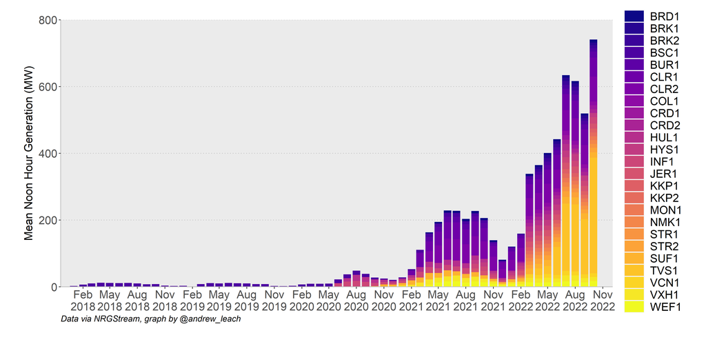

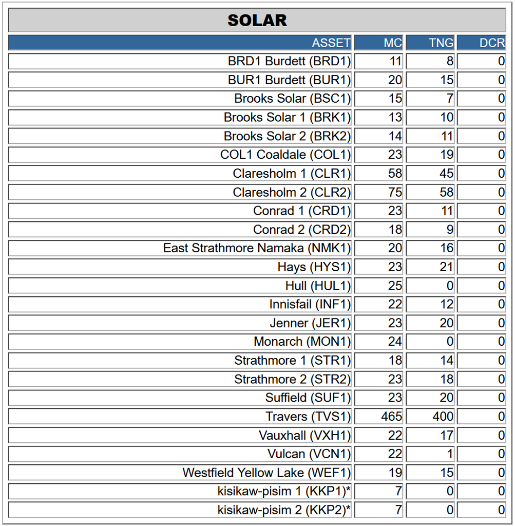

Graph: Andrew Leach

# Oil

## Weekly Crude Prices

### Feature Crude

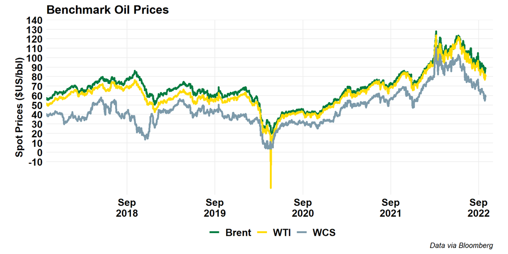

### Alberta Crude

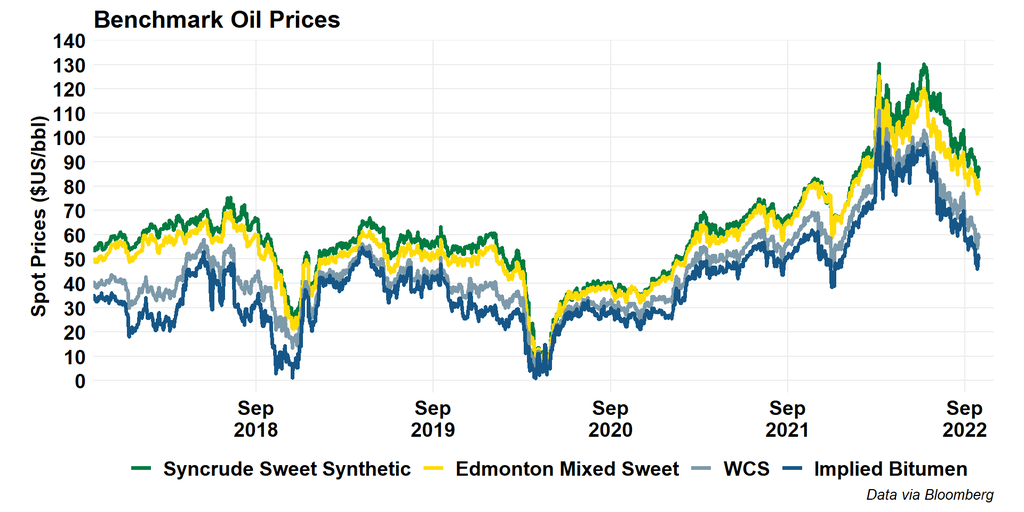

### Alberta Crude (Short)

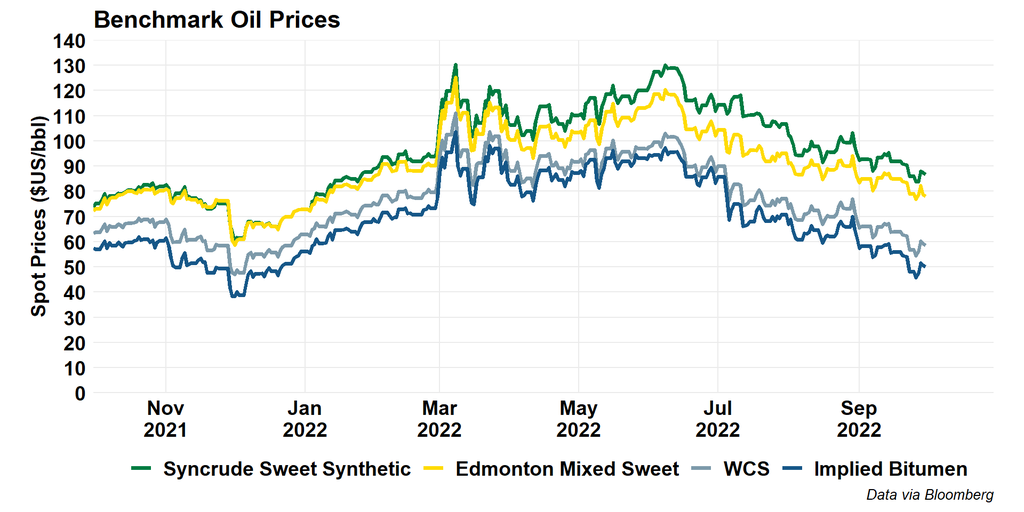

### US Crude

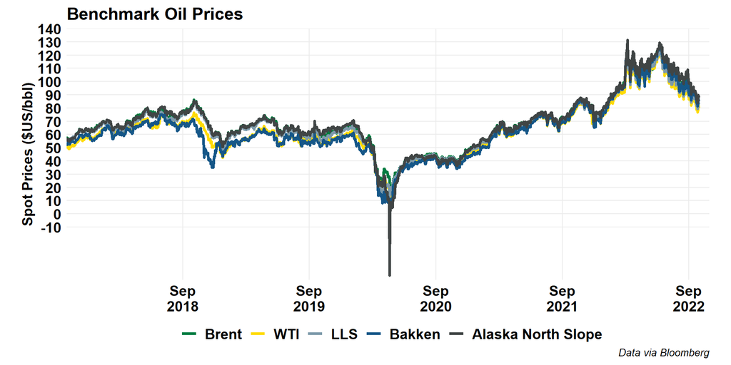

### Global Crude

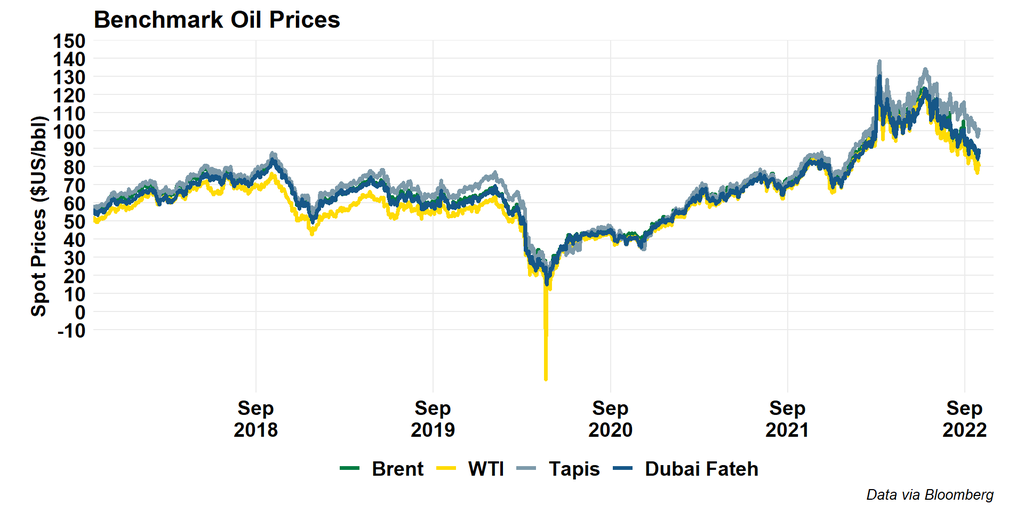

## Oil Price Differentials

### Brent-WTI

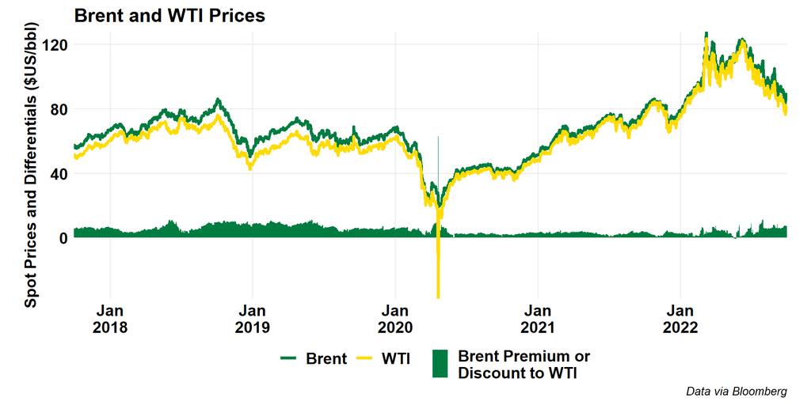

### WTI-WCS

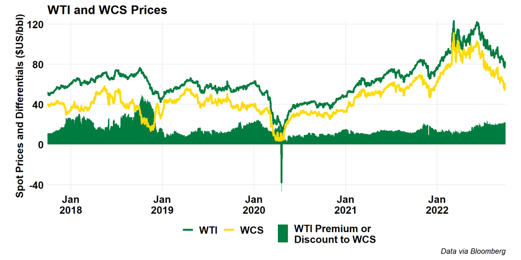

### WTI-WCS (Short)

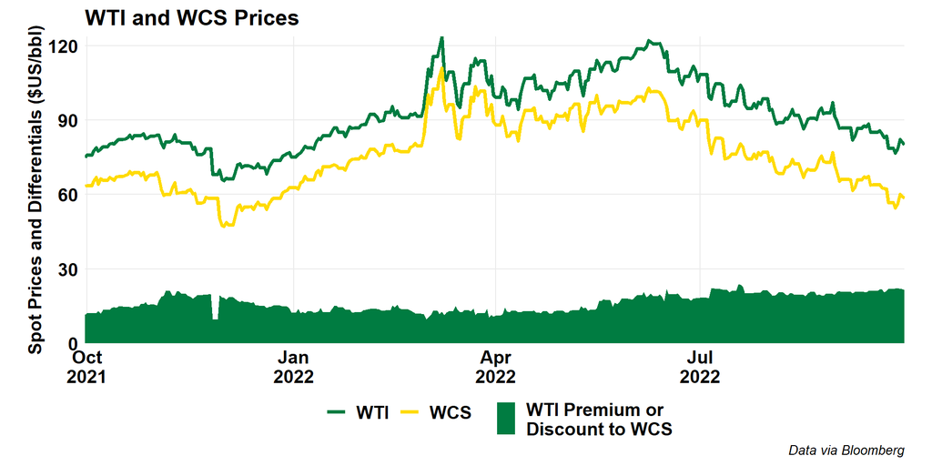

### Maya-WCS

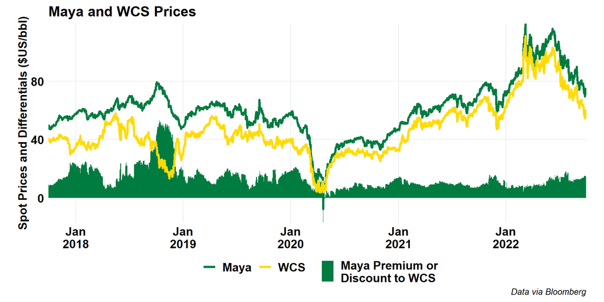

### WTI Cushing vs MEH

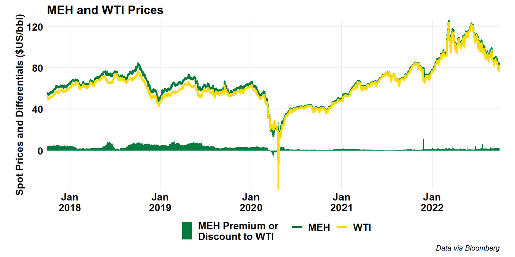

## Forward Curves

### WTI

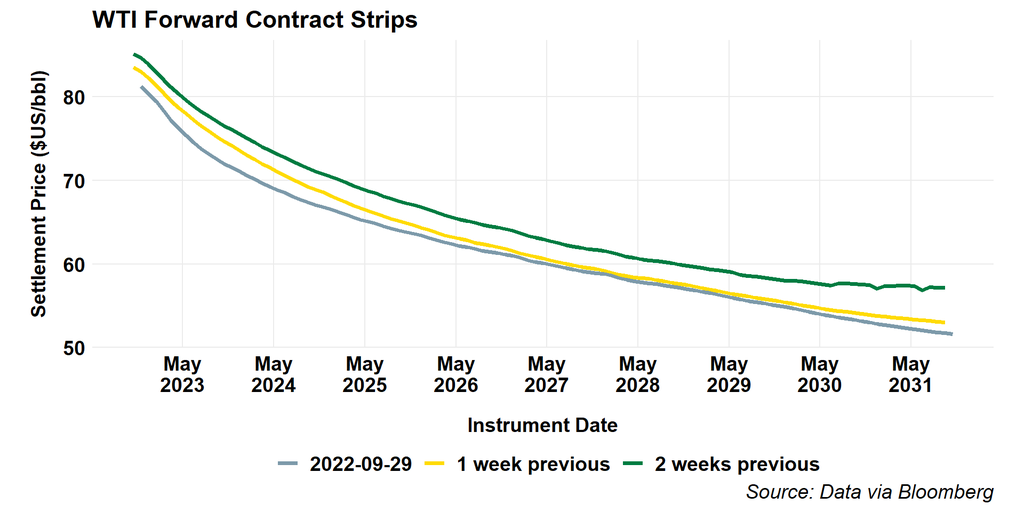

### Brent

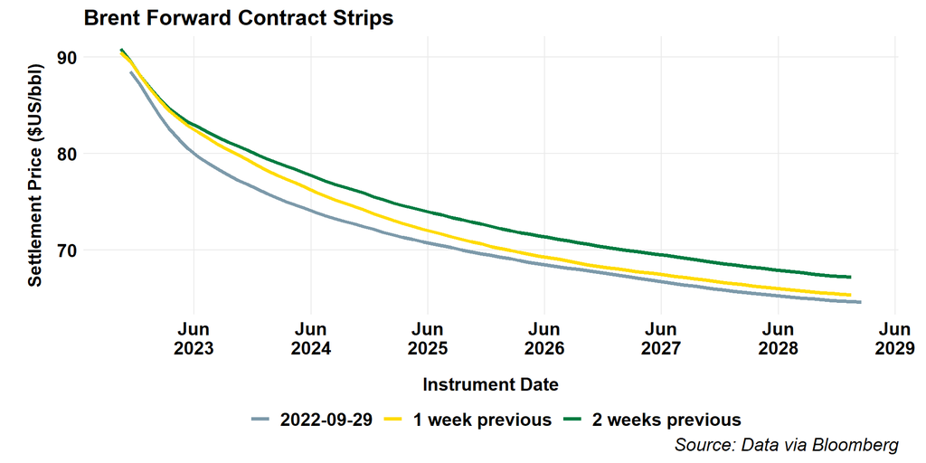

## Canadian Crude Supply and Disposition

### Production

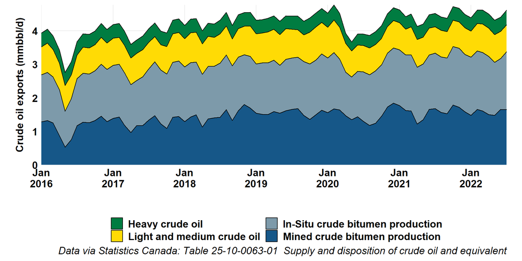

### Alberta Production

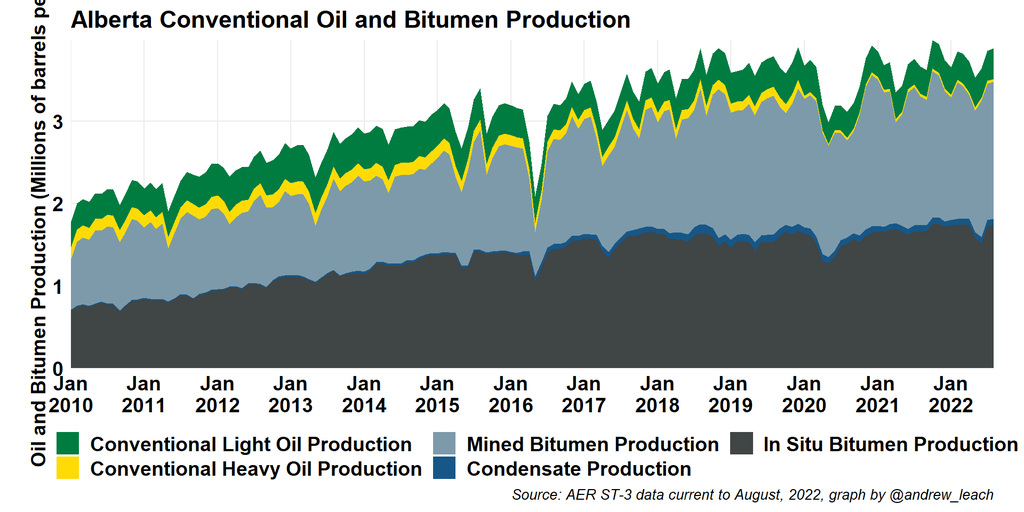

### Imports

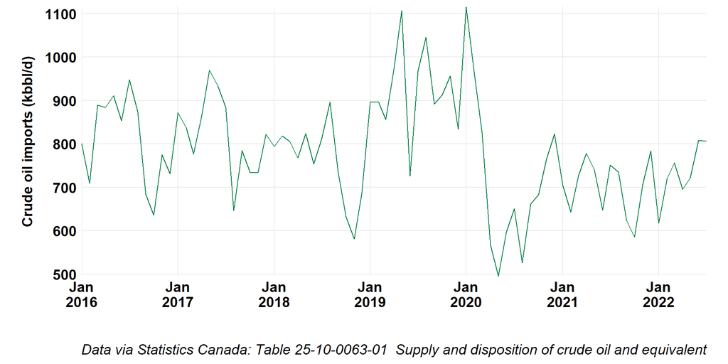

### Exports

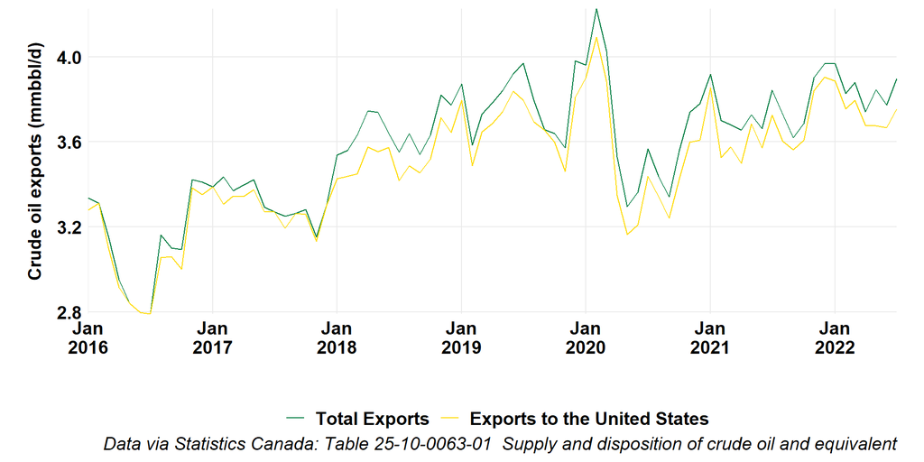

### Rail Exports

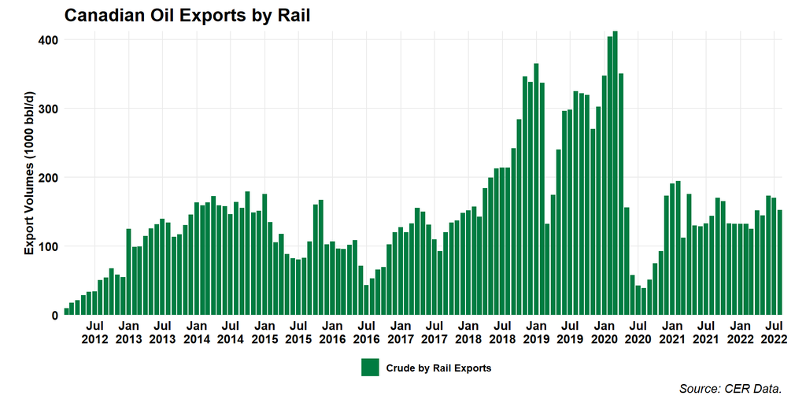

## US Oil

### Production

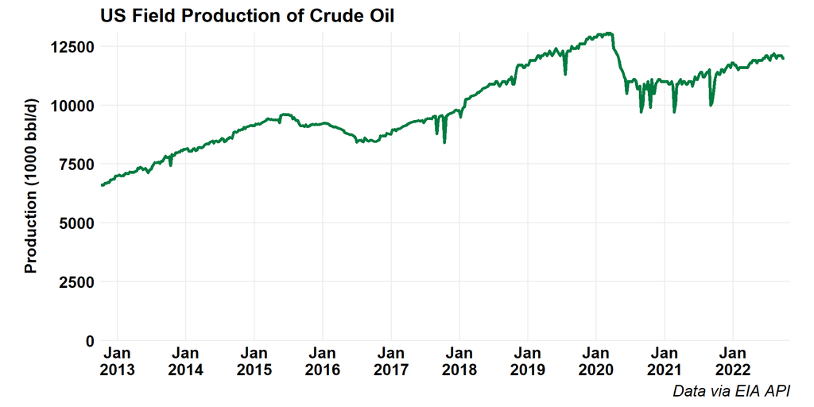

### LTO Production by Play

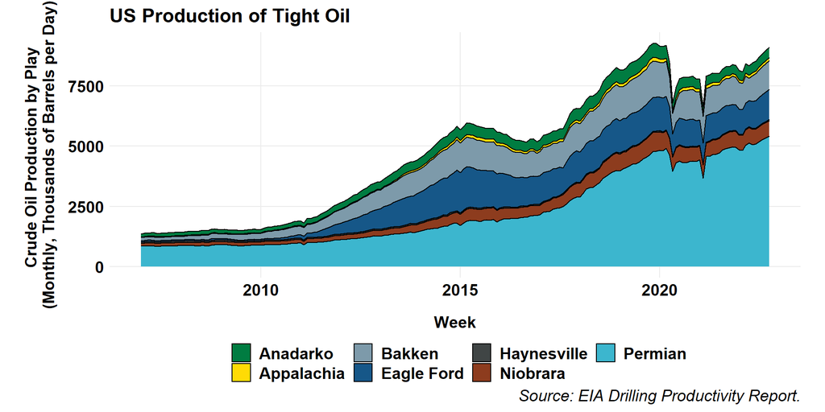

### Net Imports

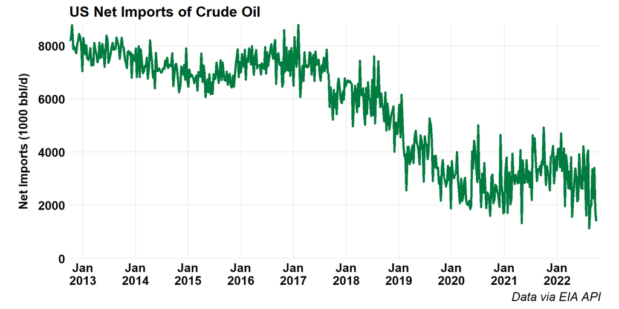

### Oil and Product Net Imports

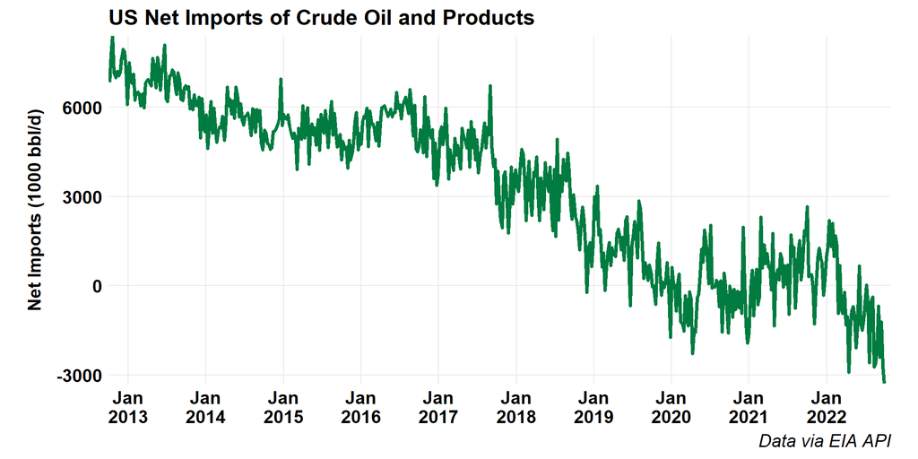

### Inventories

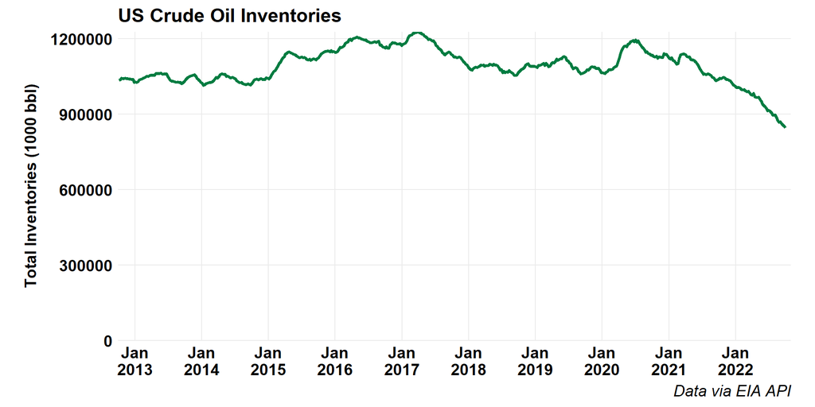

### EIA STEO Forecasts

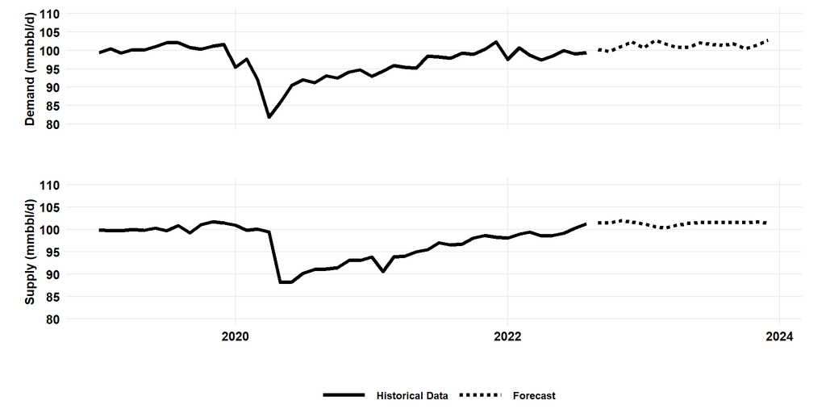

# Refined Products

## Canadian Gasoline Prices

### Map

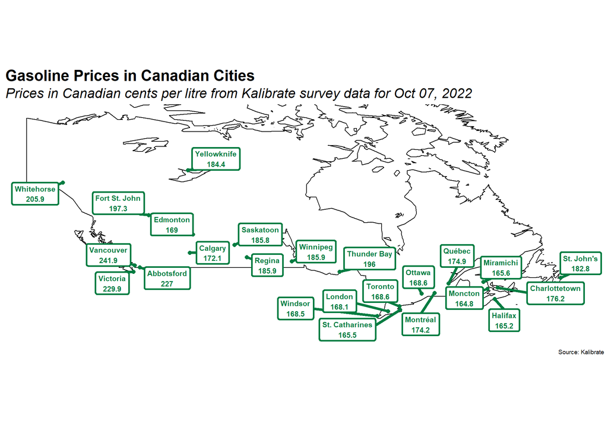

### Historic Gasoline Prices

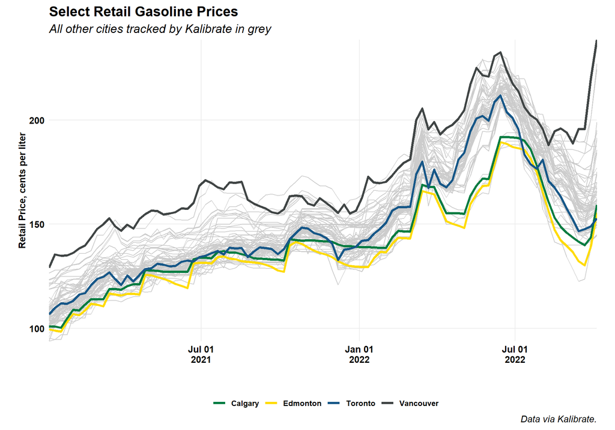

### Historic Gasoline Prices in BTC

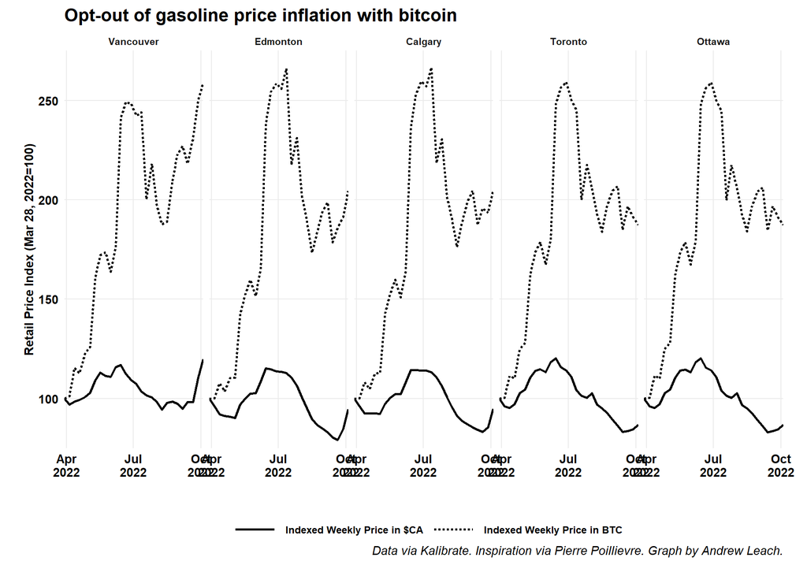

### Historic Diesel Prices

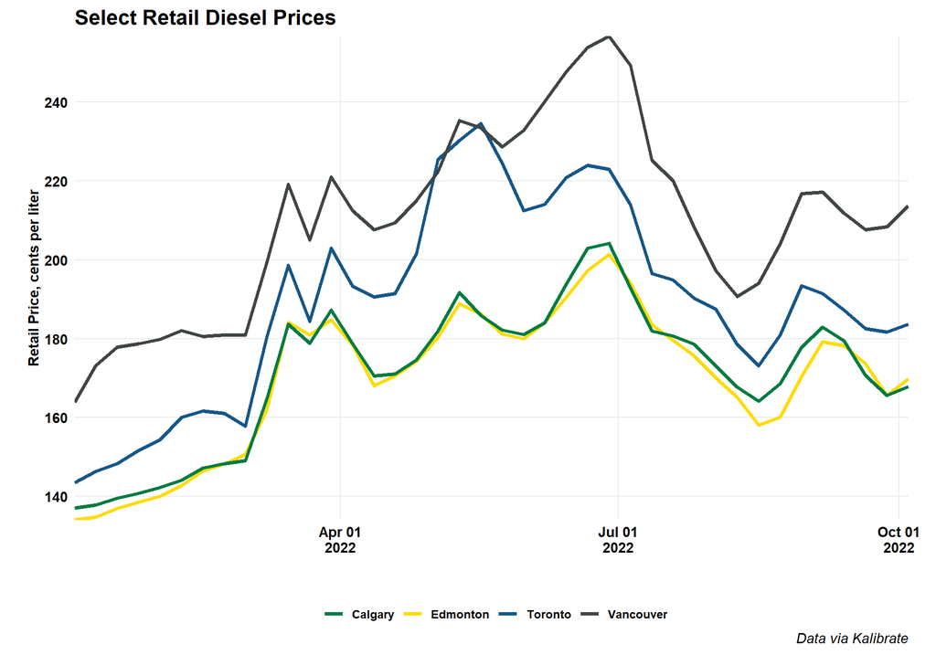

## Canadian Refinery Runs

### Canadian Refinery Runs

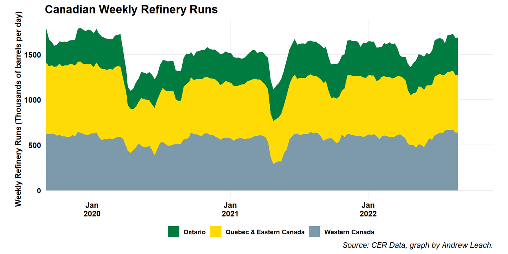

### Western Canada Refinery Runs

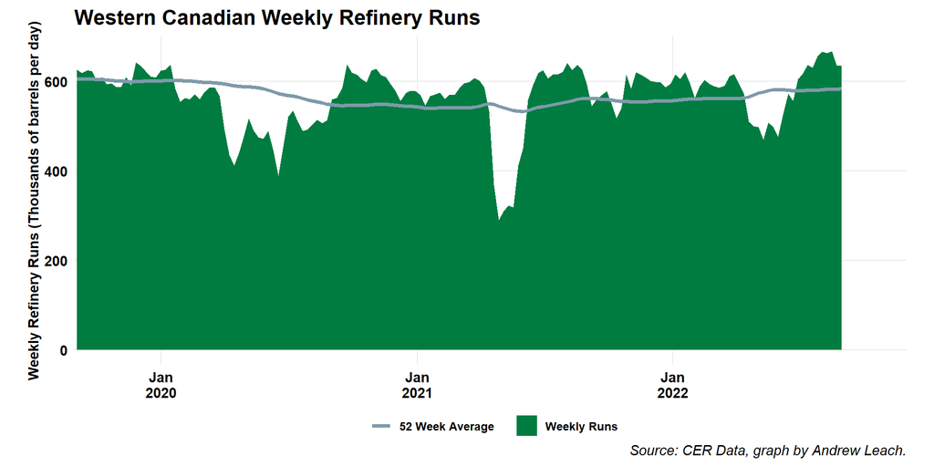